# AS04_scraping_json

10/10/2019

# Loading packages

```r
library(tidyverse)
library(httr)
library(jsonlite)
library(lubridate)
options(stringsAsFactors = F)
```

# Scraping ubike data

- Here is the ubike json data link https://tcgbusfs.blob.core.windows.net/blobyoubike/YouBikeTP.json
- You are asked to scrape youbike data per 5 minutes, continuing at least 12 hours.
- Saving each ubike json per 5 minutes with file name containing timestamp, which means you should have at least 12*12 files

```r
url <- "https://tcgbusfs.blob.core.windows.net/blobyoubike/YouBikeTP.json"
GET(url) %>% content("text") %>% cat(file = "test.json")
```

```
## No encoding supplied: defaulting to UTF-8.
```

```r
read_json("test.json") %>% class
```

```
## [1] "list"
```

```r
for(i in 1:5){
    message(i, "\t", now())
    Sys.sleep(3)
}
```

```
## 1    2019-10-19 18:47:13
```

```
## 2    2019-10-19 18:47:16
```

```
## 3    2019-10-19 18:47:19
```

```
## 4    2019-10-19 18:47:22
```

```
## 5    2019-10-19 18:47:25
```

```r
# Converting datetime to character
now() %>% format("%Y%m%d%H%M%S")
```

```
## [1] "20191019184728"
```

```r
# Listing all files in a sub-folder
list.files("data/", ".*\\.rds")
```

```
## [1] "rent5911018.rds" "stopWords.rds"   "typhoon.rds"
```

```r
# If you pud your data in a sub-folder, you need to use full name to access them.
list.files("data/", ".*\\.rds", full.names = T)
```

```
## [1] "data//rent5911018.rds" "data//stopWords.rds"   "data//typhoon.rds"
```

```r
url <- "https://tcgbusfs.blob.core.windows.net/blobyoubike/YouBikeTP.json"

for(i in 1:144){
    message(i, "\t", now())
    ctime <- now() %>% format("%Y%m%d%H%M%S")
    fname <- str_c("ubike_",ctime,".json")

    GET(url) %>% content("text") %>% cat(file = fname)

    Sys.sleep(300)
}
```

## **Q1.1 ANS** list files

- Using `list.files()` to list json files you scraped
- Using `length` to calculate `list.files()` result to see how many json files you have.

```r
fnames <- list.files(".", "ubike.")
fnames
```

```
##   [1] "ubike_20191019020940.json" "ubike_20191019021445.json"
##   [3] "ubike_20191019021950.json" "ubike_20191019022451.json"
##   [5] "ubike_20191019022952.json" "ubike_20191019023452.json"
##   [7] "ubike_20191019023952.json" "ubike_20191019024453.json"
##   [9] "ubike_20191019024953.json" "ubike_20191019025454.json"
##  [11] "ubike_20191019025954.json" "ubike_20191019030455.json"
##  [13] "ubike_20191019030955.json" "ubike_20191019031455.json"
##  [15] "ubike_20191019031956.json" "ubike_20191019032456.json"
##  [17] "ubike_20191019032957.json" "ubike_20191019033458.json"
##  [19] "ubike_20191019033958.json" "ubike_20191019034458.json"
##  [21] "ubike_20191019034959.json" "ubike_20191019035459.json"
##  [23] "ubike_20191019040000.json" "ubike_20191019040500.json"
##  [25] "ubike_20191019041000.json" "ubike_20191019041501.json"
##  [27] "ubike_20191019042001.json" "ubike_20191019042501.json"
##  [29] "ubike_20191019043002.json" "ubike_20191019043502.json"
```

[output cut: 57 more lines]

```r
length(fnames)
```

```
## [1] 144
```

## Q1.2

- Reading JSON files one by one
- Converting them to data frame individually
- Defining one indicator: fullness = sbi/tot
- Calculating each site’s fullness by time

```r
print(fnames[1])
```

```
## [1] "ubike_20191019020940.json"
```

```r
fn <- fnames[1]
f <- fromJSON(fn)


f.df <- f$retVal %>%
  unlist() %>%
  matrix(byrow = TRUE, ncol = 14) %>%
  as.data.frame() %>%
  select(11,3,4,10) %>%
  rename("id" = V11, "tot" = V3, "sbi" = V4, "dist"= V10) %>%
  mutate("time"= str_c(str_sub(fn, 15, 16), ":", str_sub(fn, 17, 18))) %>%
  mutate("fullness" = as.numeric(sbi)/as.numeric(tot)) %>%
  select(1, 4, 5, 6)
```

```r
f.full <- f.df

for(fn in fnames[-1]){
  f <- fromJSON(fn)

  temp <- f$retVal %>%
  unlist() %>%
  matrix(byrow = TRUE, ncol = 14) %>%
  as.data.frame() %>%
  select(11,3,4,10) %>%
  rename("id" = V11, "tot" = V3, "sbi" = V4, "dist" = V10) %>%
  mutate("time"= str_c(str_sub(fn, 15, 16), ":", str_sub(fn, 17, 18))) %>%
  mutate("fullness" = as.numeric(sbi)/as.numeric(tot)) %>%
  select(1, 4, 5, 6)

  f.full <- bind_rows(f.full, temp)
}

glimpse(f.full)
```

```
## Observations: 57,600
## Variables: 4
## $ id       <chr> "MRT Taipei City Hall Stataion(Exit 3)-2", "MRT S.Y.S …
## $ dist     <chr> "Xinyi Dist.", "Daan Dist.", "Xinyi Dist.", "Xinyi Dis…
## $ time     <chr> "02:09", "02:09", "02:09", "02:09", "02:09", "02:09", …
## $ fullness <dbl> 0.14444444, 0.08333333, 0.30000000, 0.10000000, 0.2500…
```

## **Q1.2 ANS**

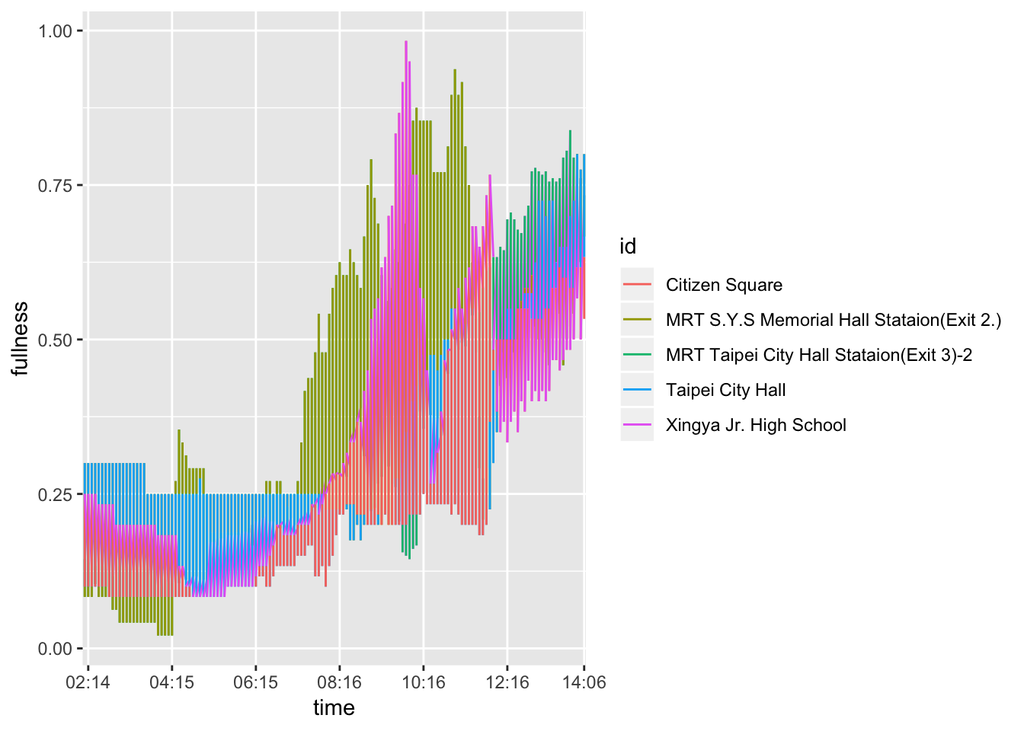

```r
#Since the data is too large to be drawn as a single plot, only choose 5 sites to be displayed.
f.temp <- f.full %>%
  filter(id %in% c("MRT Taipei City Hall Stataion(Exit 3)-2", "MRT S.Y.S Memorial Hall Stataion(Exit 2.)", "Taipei City Hall", "Citizen Square", "Xingya Jr. High School"))

ggplot(f.temp, aes(x = time, y = fullness, col = id, group = 1)) +
  geom_line() + scale_x_discrete(breaks = c("02:14","04:15","06:15","08:16","10:16","12:16","14:06"))
```

# Q2.Scraping dcard forum (No extra point if you have solved the Q1 succesfully)

- (If you cannot solve Q1 successfully, try to solve the Q2)
- Selecting one chatting forum and Scraping at least 3 pages by for-loop (You must find out the rule of url formatting, and use for-loop to scrap at least 3 pages back)
- e.g., https://www.dcard.tw/f/relationship
- One video tutorial has introduced how to find out dcard forum’s JSON data page by page.
- Adding code chunks as you need below

## **Q2.1.ANS** Print out class and dimension of your data

```r
# your code here
```

## **Q2.2.ANS** Using bar chart to show the number of post trend by week.

```r
# your code here
```

# (No extra point) Discovering one more website generated by JSON

## **Q3.ANS** Print out glimpse(), class, and dimension of your data

```r
# YOUR CODE SHOULD BE HERE
```